# Before we get started: Getting Organized

- Over ~10 years of working with graduate students + postdocs, I've noticed something.
- Organized researchers get more done (and better!).
- Many of them are more organized than I am!
- Thought: I should get organized; I should help others get organized.

# So what can you do?

- Buy a notebook; bring it to meetings; make notes!
- Come to meetings with a written agenda.
- While doing research, record what you did and what the outcome was.
- Use version control ([git](http://git-scm.com)) and internet repositories ([bitbucket](http://www.bitbucket.org), [github](http://www.github.com)) to organize notes, code, etc.
- Use *knitr* to help make your research reproducible.

# What are these repository things?

- A repository: a central place in which an aggregation of data is kept and maintained in an organized way (searcharticle.com)
- Great for sharing material across multiple people (eg student and advisor!)
- An amateur example: http://github.com/stephens999/ash

# What is knitr?

- An R package
- A tool for literate programming
- Text, and R code are interleaved
- When you compile the document, the code is run, and output inserted into the text.
- Great for writing reports, and keeping a track of what you did and what the result was!
- This talk was written with knitr (with RStudio)!

# What is Reproducible Research?

- Principle: when publishing results of computational procedures, we should publish the code that produced the results.
- “publishing figures or results without the complete software environment could be compared to a mathematician publishing an announcement of a mathematical theorem without giving the proof” (Buckheit and Donohoe)
- “an article about a computational result is advertising, not scholarship. The actual scholarship is the full software environment, code and data, that produced the result.” [Claerbout]

# Why is reproducibility important?

- Not only because people are forgetful, error-prone, or dishonest!
- Reproducing work is also the first step to extending it.
- Helps communications among researchers (eg student + advisor).
- If you do not publish code implementing your methods, your methods will likely go unused.

# More on git, github, knitr, reproducibility

- Google “The git book”, to get started on git.
- Google “Karl Broman github tutorial” for statistics-oriented intro to github.
- Google “donohoe buckheit” for “Wavelab and reproducible research”

# The Canonical Genomics Experiment

- Measure lots of things, with error
- Get estimates of effects \( \beta_j \) (\( \hat\beta_j \)) and their standard errors \( s_j \)
- Turn these into Z-scores, \( z_j = \hat\beta_j/s_j \)
- Turn these into \( p \) values, \( p_j \)
- Apply `qvalue` to identify findings “significant” at a given False Discovery Rate.
- …?

# FDR, local fdr, and q values

# Example: FDR estimation

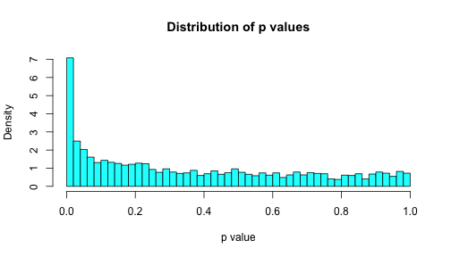

# Example: FDR estimation

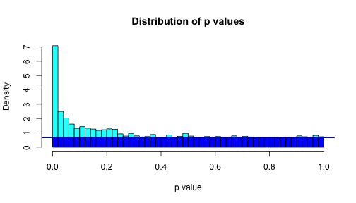

Data from Hedenfalk et al, comparing BRCA1 vs BRCA2 expression.

# Example: FDR estimation

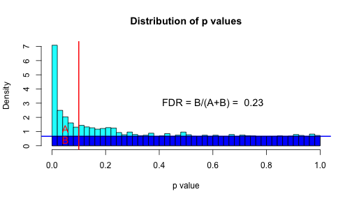

# Example: fdr estimation

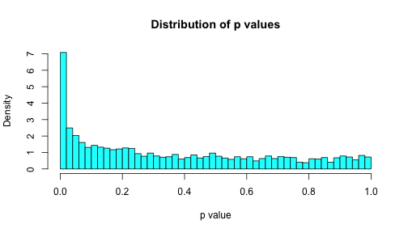

# Example: fdr estimation

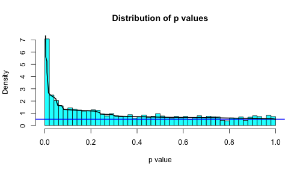

# Example: fdr estimation

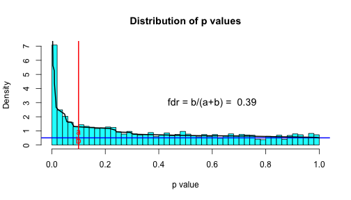

# FDR problem 1: different measurement precision

- If some effects are measured very imprecisely, those tests “lack power” and simply add noise
- In particular, such tests increase the estimated number of nulls, and increase the FDR for other tests
- It would seem preferable to simply ignore the tests with very low precision. Summarizing each test by a \( p \) value (or \( Z \) score) loses the information about precision.

# Example: Mouse Heart Data

```
##      gene  lv1  lv2   rv1   rv2 genelength
## 1   Itm2a 2236 2174  9484 10883       1626
## 2  Sergef   97   90   341   408       1449
## 3 Fam109a  383  314  1864  2384       2331
## 4    Dhx9 2688 2631 18501 20879       4585
## 5   Ssu72  762  674  2806  3435       1446
## 8  Eif2b2  736  762  3081  3601       1565
```

# Example: Mouse Heart Data

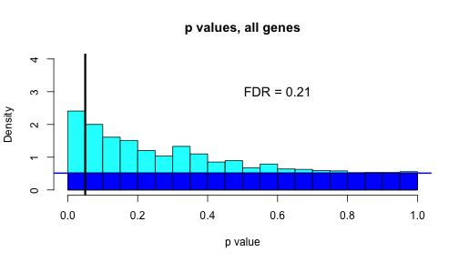

# Mouse Data: Counts vary considerably across genes

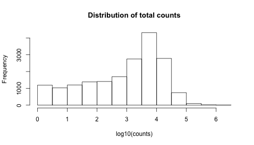

# Lower count genes, less power

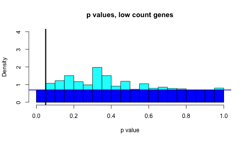

# Higher count genes, more power

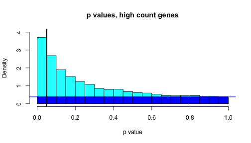

# FDR problem 1: low count genes add noise, increase q values

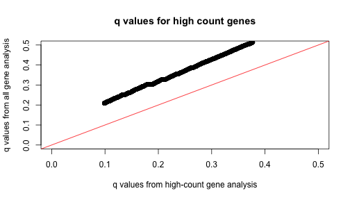

# FDR problem 1: Summary

- Analyzing \( p \) values or \( Z \) scores doesn't fully account for measurement precision.

# Problem 2: The Zero Assumption (ZA)

- The standard `qvalue` approach assumes that all the \( p \) values near 1 are null.
- Analogously, one can assume that all Z scores near 0 are null. Efron refers to this as the “Zero Assumption”.
- The ZA allows us to estimate the null proportion, \( \pi_0 \), using the density of \( p \) values near 1 (or \( Z \) scores near 0).

# Problem 2: The ZA

- The ZA seems initially natural.
- However, it turns out to imply unrealistic assumptions about the distribution of non-zero effects.

# Implied distribution of \( p \) values under \( H_1 \)

[figure not shown]

# Implied distribution of Z scores under alternative (fdrtool)

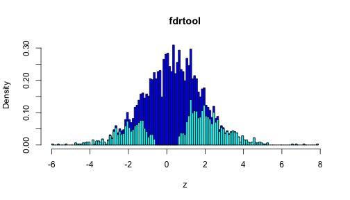

# Implied distribution of Z scores under alternative (locfdr)

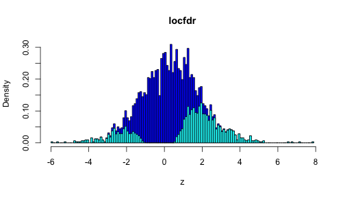

# Implied distribution of Z scores under alternative (mixfdr)

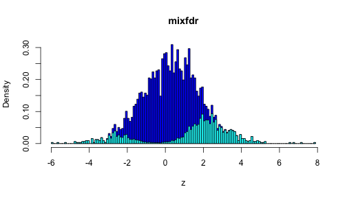

# Problems: Summary

- By summarizing each observation by a \( Z \) score or \( p \) value, standard fdr tools ignore precision of different measurements
- Standard tools make the ZA, which implies actual effects have a (probably unrealistic) bimodal distribution. [and tends to overestimate \( \pi_0 \), losing power]
- Also standard tools focus only on zero vs non-zero effects. (eg what if we would like to identify genes that have at least a 2-fold change?)

# FDR via Empirical Bayes

- Following previous work (e.g. Newton, Efron, Muralidharan) we take an empirical Bayes approach to FDR.
- Eg Efron assumes that the \( Z \) scores come from a mixture of null, and alternative: \[ Z_j \sim f_Z(.) = \pi_0 N(.;0,1) + (1-\pi_0) f_1(.) \] where \( f_1 \) is to be estimated from the data.
- Various semi-parametric approaches taken to estimating \( f_1 \). For example, Efron uses Poisson regression; Muralidharan uses mixture of normal distributions.
- \( \text{fdr}(Z) \approx \pi_0 N(Z; 0,1)/ f_Z(Z) \)

# FDR: The New Deal

- Instead of modelling \( Z \) scores, model the effects \( \beta \), \[ \beta_j \sim \pi_0 \delta_0(.) + (1-\pi_0) g(.) \]
- Constrain \( g \) to be unimodal about 0; estimate \( g \) from data.
- *Incorporate precision* of each observation \( \hat\beta \) into the likelihood. Specifically, approximate likelihood for \( \beta_j \) by a normal: \[ L(\beta_j) \propto \exp(-0.5 (\beta_j - \hat\beta_j)^2/s_j^2). \] [From \( \hat\beta_j \sim N(\beta_j, s_j) \)]
- fdr given by \[ p(\beta_j =0 | \hat\beta_j) = \pi_0 p(\hat\beta_j | \beta_j=0)/p(\hat\beta_j) \]

# FDR - A New Deal

- A convenient way to model \( g \) is by a mixture of 0-centered normal distributions: \[ g(\beta; \pi) = \sum_{k=1}^K \pi_k N(\beta; 0, \sigma^2_k) \]
- Estimating \( g \) comes down to estimating \( \pi \). Joint estimation of \( \pi_0,\pi \) easy by maximum likelihood (EM algorithm) or variational Bayes.
- By allowing \( K \) large, and \( \sigma_k \) to span a dense grid of values, we get a fairly flexible unimodal symmetric distribution.
- Can approximate, arbitrarily closely, any scale mixture of normals. Includes almost all priors used for sparse regression problems (spike-and-slab, double exponential/Laplace/Bayesian Lasso, horseshoe).

# FDR - A New Deal

- Alternatively, a mixture of uniforms, with 0 as one end-point of the range, provides still more flexibility, and in particular allows for asymmetry.
- If allow a very large number of uniforms this provides the non-parametric mle for \( g \); cf Grenander 1953; Campy + Thomas.

# Illustration: \( g \) a mixture of 0-centered normals

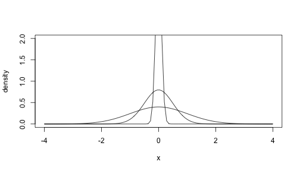

# Illustration: \( g \) a mixture of 0-centered normals

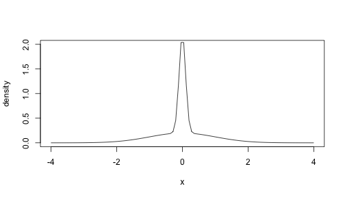

# Illustration: \( g \) a mixture of 0-anchored uniforms

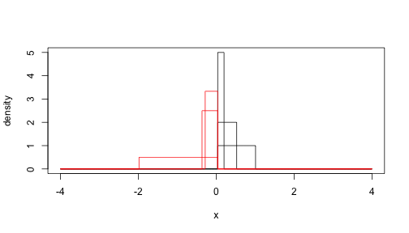

# Illustration: \( g \) a mixture of 0-anchored uniforms

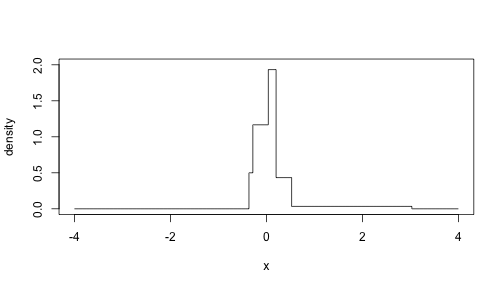

# Issue: identifiability of \( \pi_0 \)

- For estimating False Discoveries, we are asking whether \( \beta_j = 0 \).
- However, the data cannot distinguish between \( \beta_j = 0 \) and \( \beta_j \) “very small”
- As a result \( \pi_0 \) is formally unidentifiable. Eg data can never rule out \( \pi_0=0 \).

# Issue: identifiability of \( \pi_0 \)

- The Zero assumption (ZA) solves the identifiability problem by assuming that there *are* no \( \beta_j \) near zero!
- The ZA makes \( \pi_0 \) identifiable.
- Another view is that the estimate of \( \pi_0 \) under ZA will systematically tend to overestimate \( \pi_0 \), and so is “conservative”.
- That is it provides an “upper bound” on \( \pi_0 \)

# Identifiability of \( \pi_0 \): Solution 1

# Illustration: Simulated Example

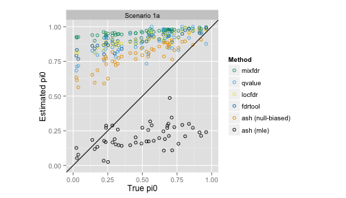

# Example: BRCA data

# Recall Problem: distribution of alternative Z values multimodal

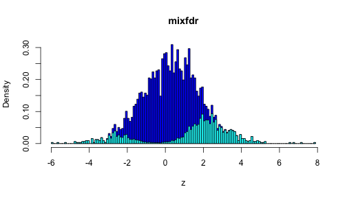

# Problem Fixed: distribution of alternative Z values unimodal

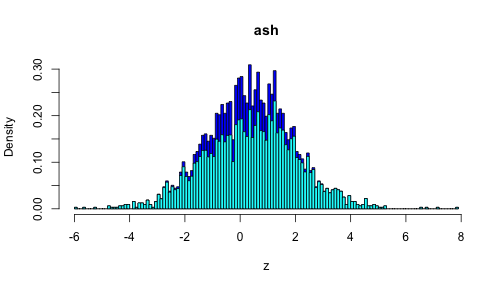

# BRCA1: Compare \( \pi_0 \) estimates

```r
round(c(hh.fdrtool$param[3], hh.locfdr$fp0[1, 3], hh.mixfdr$pi[1], hh.ashz$fitted.g$pi[1]),
    2)
```

```
## [1] 0.64 0.74 0.80 0.21
```

# BRCA1: Compare number significant at fdr<0.05

```r
c(sum(hh.fdrtool$lfdr < 0.05), sum(hh.locfdr$fdr < 0.05), sum(hh.mixfdr$fdr <
    0.05), sum(hh.ashz$ZeroProb < 0.05))
```

```
## [1] 154 171 162 341
```

# Identifiability of \( \pi_0 \) and the False Sign Rate

- Identifiability of \( \pi_0 \) is primarily an issue if we insist on asking question is \( \beta_j=0 \)?
- How about we change focus: assume *none* of the \( \beta_j \) are zero (“one group approach”), and ask for which \( \beta_j \) are we confident about the sign (Gelman et al, 2012).
- Positive and negative effects are often treated differently in practice anyway.
- That is we replace fdr with False Sign Rate (fsr), the probability that if we say an effect is positive (negative), it is not.
- Example: suppose we estimate that \( \Pr(\beta_j<0)=0.975 \) and \( \Pr(\beta_j>0)=0.025 \). Then we report \( \beta_j \) as a “(negative) discovery”, and estimate its fsr as 0.025.

# The fsr is more robust than fdr

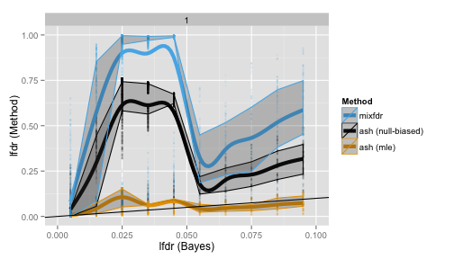

# The fsr is more robust than fdr

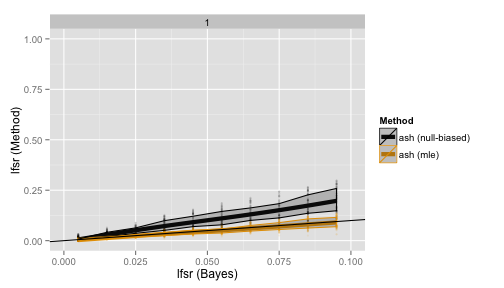

# Estimation and Shrinkage

- Besides allowing one to estimate fdr and fsr, this approach also provides a full posterior distribution for each \( \beta_j \).
- So for example we can easily compute fdrs for discoveries other than “non-zero” (eg compute \( \Pr(\beta_j > 2 | \hat\beta_j) \)).
- And use it to obtain point estimates and credible intervals for each \( \beta_j \), taking account of information from all the other \( \beta_j \).
- Because \( f(\beta) \) is unimodal, the point estimates will tend to be “shrunk” towards the overall mean (0).
- Because \( f(\beta) \) is estimated from the data, the amount of shrinkage is adaptive to the data. And because of the role of \( s_j \), the amount of shrinkage adapts to the information on each gene.
- So we call the approach “Adaptive Shrinkage” (ASH).

# Example: ASH applied to mouse data

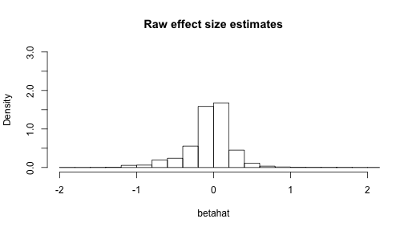

# Example: ASH applied to mouse data

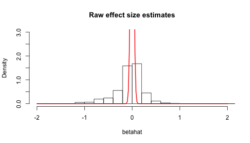

# Example: ASH applied to mouse data

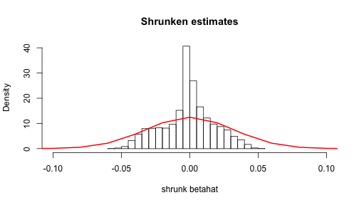

# Example: ASH applied to mouse data

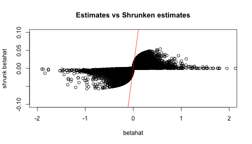